```r
library(lubridate)
library(dplyr)
```

```r
library(ggplot2)
library(maps)
library(stringr)
library(tidyverse)
library(corrplot)
library(moments)
```

### DATA PREPROCESSING

```r
data<- read.csv("Marketing-Customer-Value-Analysis.csv", header = TRUE)
df = read.csv("Marketing-Customer-Value-Analysis.csv", header = TRUE)
num_data <- unlist(lapply(data, is.numeric))
mdy <- mdy(data$Effective.To.Date)
dmy <- dmy(data$Effective.To.Date)
mdy[is.na(mdy)] <- dmy[is.na(mdy)]
data$Effective.To.Date <- mdy
colnames(df)
```

```
##  [1] "Customer"                      "State"
##  [3] "CLV"                           "Response"
##  [5] "Coverage"                      "Education"
##  [7] "Effective.To.Date"             "EmploymentStatus"
##  [9] "Gender"                        "Income"
## [11] "Location.Code"                 "Marital.Status"
## [13] "Monthly.Premium.Auto"          "Months.Since.Last.Claim"
## [15] "Months.Since.Policy.Inception" "Number.of.Open.Complaints"
## [17] "Number.of.Policies"            "Policy.Type"
## [19] "Policy"                        "Renew.Offer.Type"
## [21] "Sales.Channel"                 "Total.Claim.Amount"
## [23] "Vehicle.Class"                 "Vehicle.Size"
```

```r
colnames(df) <- str_replace_all(colnames(df),"[.]","")
colnames(df)
```

```
##  [1] "Customer"                   "State"
##  [3] "CLV"                        "Response"
##  [5] "Coverage"                   "Education"
##  [7] "EffectiveToDate"            "EmploymentStatus"
##  [9] "Gender"                     "Income"
## [11] "LocationCode"               "MaritalStatus"
## [13] "MonthlyPremiumAuto"         "MonthsSinceLastClaim"
## [15] "MonthsSincePolicyInception" "NumberofOpenComplaints"
## [17] "NumberofPolicies"           "PolicyType"
## [19] "Policy"                     "RenewOfferType"
## [21] "SalesChannel"               "TotalClaimAmount"
## [23] "VehicleClass"               "VehicleSize"
```

```r
sapply(df, data.table::uniqueN)
```

```
##                   Customer                      State
##                       9134                          5
##                        CLV                   Response
##                       8041                          2
##                   Coverage                  Education
##                          3                          5
##            EffectiveToDate           EmploymentStatus
##                         59                          5
##                     Gender                     Income
##                          2                       5694
##               LocationCode              MaritalStatus
##                          3                          3
##         MonthlyPremiumAuto       MonthsSinceLastClaim
##                        202                         36
## MonthsSincePolicyInception     NumberofOpenComplaints
##                        100                          6
##           NumberofPolicies                 PolicyType
##                          9                          3
##                     Policy             RenewOfferType
##                          9                          4
##               SalesChannel           TotalClaimAmount
##                          4                       5106
##               VehicleClass                VehicleSize
##                          6                          3
```

```r
sum(is.na(data))
```

```
## [1] 0
```

Here we can observe that there are no missing values in the data

```r
summary(data)
```

```
##    Customer            State                CLV          Response
##  Length:9134        Length:9134        Min.   : 1898   Length:9134
##  Class :character   Class :character   1st Qu.: 3994   Class :character
##  Mode  :character   Mode  :character   Median : 5780   Mode  :character
##                                        Mean   : 8005
##                                        3rd Qu.: 8962
##                                        Max.   :83325
##    Coverage          Education         Effective.To.Date    EmploymentStatus
##  Length:9134        Length:9134        Min.   :2011-01-01   Length:9134
##  Class :character   Class :character   1st Qu.:2011-01-15   Class :character
##  Mode  :character   Mode  :character   Median :2011-01-29   Mode  :character
##                                        Mean   :2011-01-29
##                                        3rd Qu.:2011-02-13
##                                        Max.   :2011-02-28
##     Gender              Income      Location.Code      Marital.Status
##  Length:9134        Min.   :    0   Length:9134        Length:9134
##  Class :character   1st Qu.:    0   Class :character   Class :character
##  Mode  :character   Median :33890   Mode  :character   Mode  :character
##                     Mean   :37657
##                     3rd Qu.:62320
##                     Max.   :99981
##  Monthly.Premium.Auto Months.Since.Last.Claim Months.Since.Policy.Inception
##  Min.   : 61.00       Min.   : 0.0            Min.   : 0.00
##  1st Qu.: 68.00       1st Qu.: 6.0            1st Qu.:24.00
##  Median : 83.00       Median :14.0            Median :48.00
##  Mean   : 93.22       Mean   :15.1            Mean   :48.06
##  3rd Qu.:109.00       3rd Qu.:23.0            3rd Qu.:71.00
##  Max.   :298.00       Max.   :35.0            Max.   :99.00
##  Number.of.Open.Complaints Number.of.Policies Policy.Type
##  Min.   :0.0000            Min.   :1.000      Length:9134
##  1st Qu.:0.0000            1st Qu.:1.000      Class :character
##  Median :0.0000            Median :2.000      Mode  :character
##  Mean   :0.3844            Mean   :2.966
##  3rd Qu.:0.0000            3rd Qu.:4.000
##  Max.   :5.0000            Max.   :9.000
##     Policy          Renew.Offer.Type   Sales.Channel      Total.Claim.Amount
##  Length:9134        Length:9134        Length:9134        Min.   :   0.099
##  Class :character   Class :character   Class :character   1st Qu.: 272.258
##  Mode  :character   Mode  :character   Mode  :character   Median : 383.945
##                                                           Mean   : 434.089
##                                                           3rd Qu.: 547.515
##                                                           Max.   :2893.240
##  Vehicle.Class      Vehicle.Size
##  Length:9134        Length:9134
##  Class :character   Class :character
##  Mode  :character   Mode  :character
##
##
##
```

### EXPLORATORY DATA ANALYSIS

#### EXPLORING THE TARGET VARIABLE

#### Statistical summary of Customer Lifetime Value

```r
range(df$CLV)
```

```
## [1]  1898.008 83325.381
```

```r
median(df$CLV)
```

```
## [1] 5780.182
```

```r
mean(df$CLV)
```

```
## [1] 8004.94
```

```r
sd(df$CLV)
```

```
## [1] 6870.968
```

```r
skewness(df$CLV)
```

```
## [1] 3.031782
```

```r
kurtosis(df$CLV)
```

```
## [1] 16.81531
```

#### Boxplot of Customer Lifetime Value

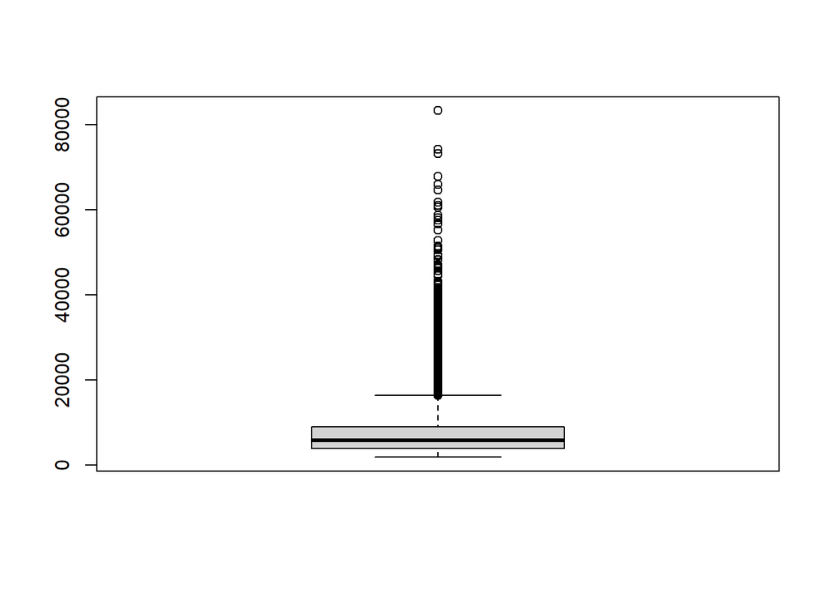

```r
boxplot(df$CLV)
```

Here we can observe that there is a significant amount of outliers for Customer Lifetime Value.

#### Histogram of Customer Lifetime Value

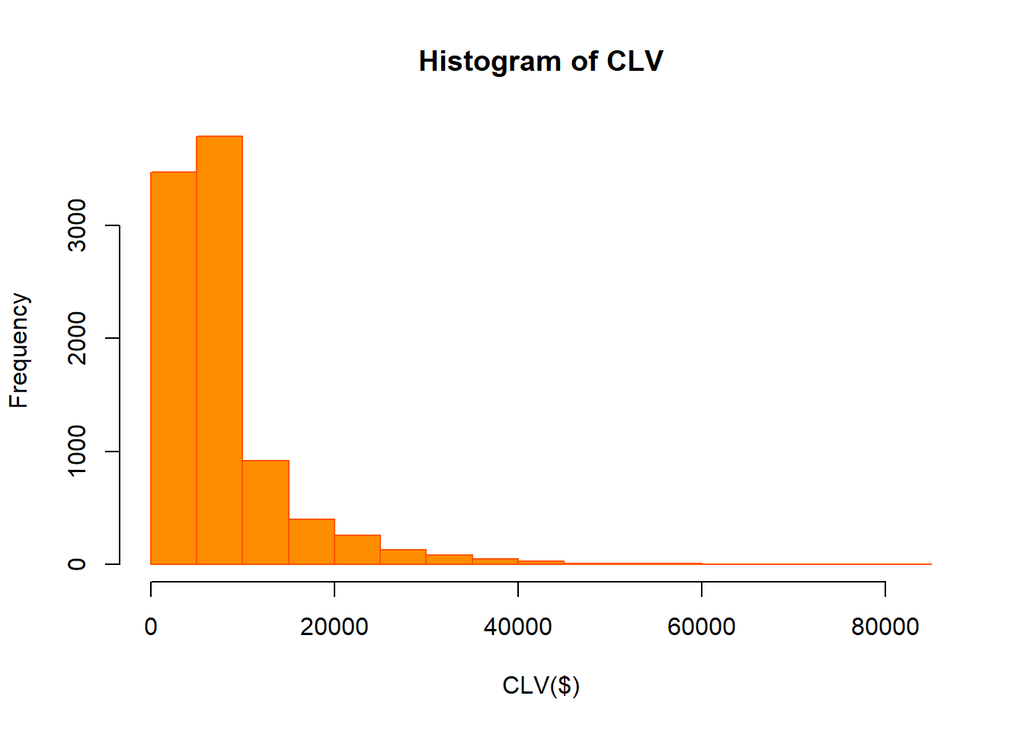

```r
hist(df$CLV,
     main = "Histogram of CLV",
     xlab = "CLV($)",
     col = "#FF8D00" ,border = "#FF5500")
```

Right skewed,implies as CLV increases customers the number of customers reduces.

#### CORRELATION OF TARGET VARIABLE WITH OTHER INDEPENDENT CONTINOUS VARIABLES

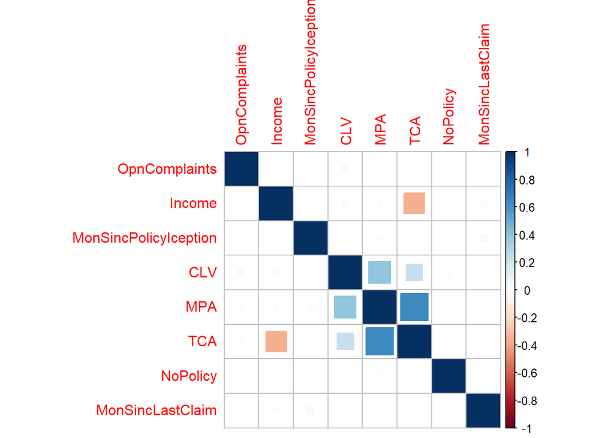

```r
corcol <- df[,c(3,10,13,14,15,16,17,22)]
colnames(corcol) <- c("CLV","Income","MPA","MonSincLastClaim",
                      "MonSincPolicyIception","OpnComplaints","NoPolicy",
                      "TCA")
corrplot(cor(corcol),method = "square",
         order = "AOE")
```

Customer Lifetime Value (CLV) shows highest positive correlations with Monthly Premiums and Total Claim Amount

#### RELATIONSHIP BETWEEN CORRELATED CONTINOUS VARIABLES AND TARGET VARIABLE

#### Statistical summary of Monthly Premium Auto

```r
range(df$ MonthlyPremiumAuto)
```

```
## [1]  61 298
```

```r
median(df$ MonthlyPremiumAuto)
```

```
## [1] 83
```

```r
mean(df$ MonthlyPremiumAuto)
```

```
## [1] 93.21929
```

```r
sd(df$ MonthlyPremiumAuto)
```

```
## [1] 34.40797
```

```r
skewness(df$MonthlyPremiumAuto)
```

```
## [1] 2.123198
```

```r
kurtosis(df$MonthlyPremiumAuto)
```

```
## [1] 9.189558
```

#### Boxplot of Monthly Premium Auto

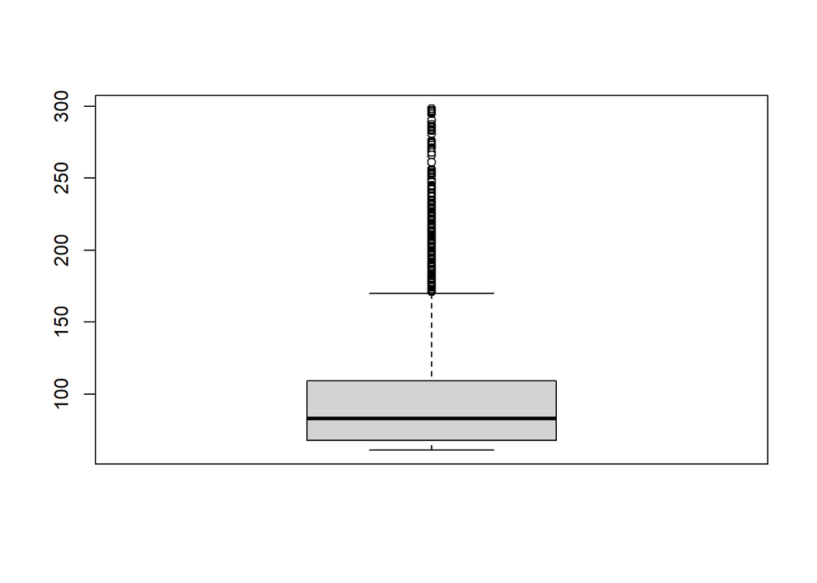

```r
boxplot(df$ MonthlyPremiumAuto)
```

There is significant number of outliers for Monthly Premium Auto variable

#### Scatterplot of Monthly Premium Auto

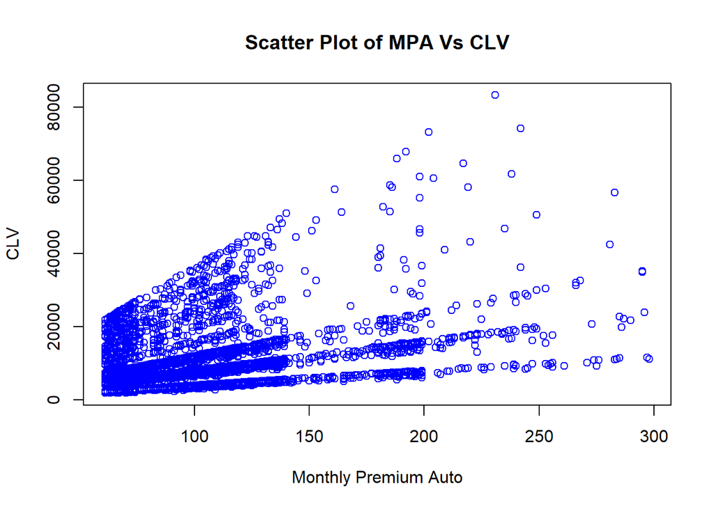

```r
plot(x = df$MonthlyPremiumAuto,y = df$CLV,
     xlab = "Monthly Premium Auto",
     ylab = "CLV",
     main = "Scatter Plot of MPA Vs CLV",
     col = "blue")
```

From scatter plot, it is clearly visible that on MPA, CLV is also Increasing.

#### Histogram of Monthly Premium Auto

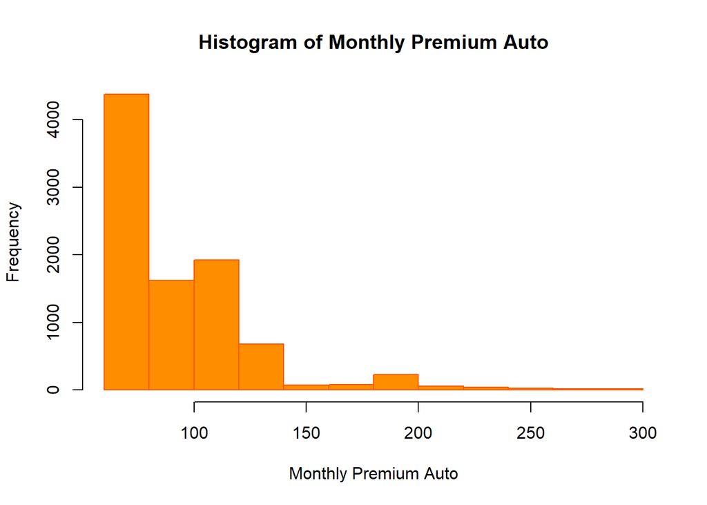

```r
hist(df$MonthlyPremiumAuto,
     main = "Histogram of Monthly Premium Auto",
     xlab = "Monthly Premium Auto",
     col = "#FF8D00" ,border = "#FF5500")
```

It is +vely skewed and most values on the left.There are many outliers in the distribution. There is a Positive Correlation of 39.62 % of MPA with CLV.

#### Statistical summary of Total Claim Amount

```r
range(df$ TotalClaimAmount)
```

```
## [1]    0.099007 2893.239678
```

```r
median(df$ TotalClaimAmount)
```

```
## [1] 383.9454
```

```r
mean(df$ TotalClaimAmount)
```

```
## [1] 434.0888
```

```r
sd(df$ TotalClaimAmount)
```

```
## [1] 290.5001
```

```r
skewness(df$TotalClaimAmount)
```

```
## [1] 1.714684
```

```r
kurtosis(df$TotalClaimAmount)
```

```
## [1] 8.975472
```

#### Boxplot of Months Total Claim Amount

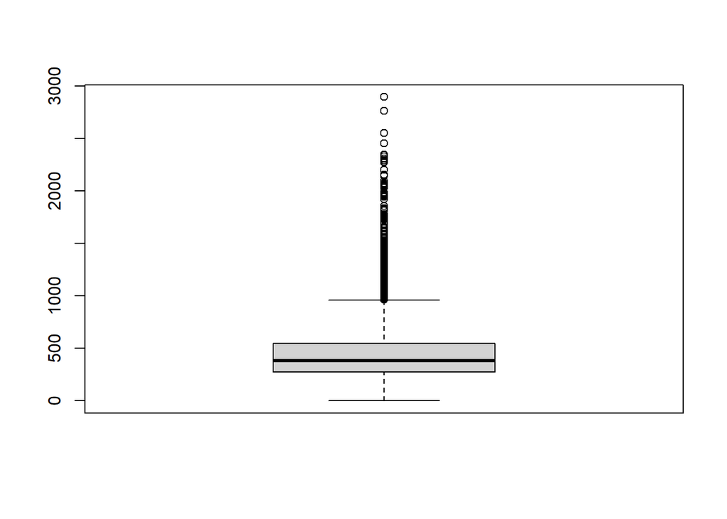

```r
boxplot(df$ TotalClaimAmount)
```

#### Scatterplot of Total Claim Amount

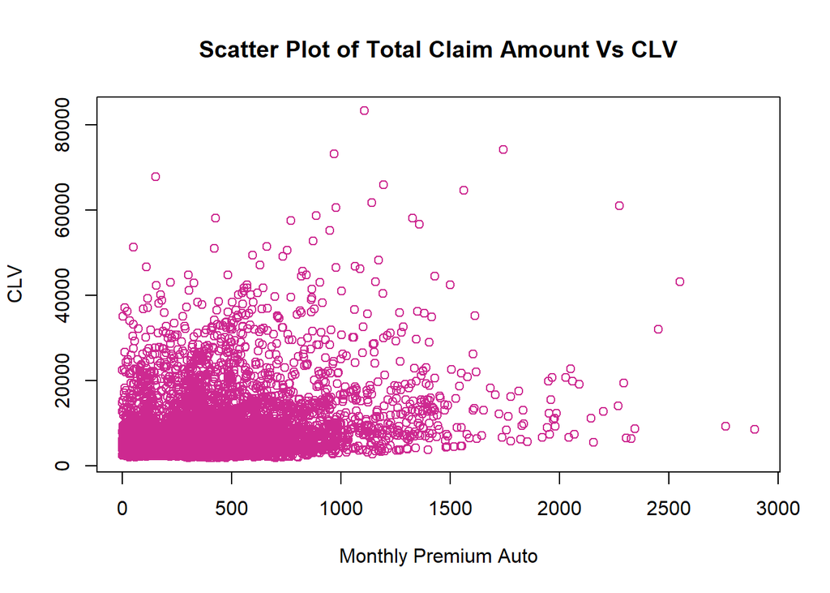

```r
plot(x = df$TotalClaimAmount,y = df$CLV,
     xlab = "Monthly Premium Auto",
     ylab = "CLV",
     main = "Scatter Plot of Total Claim Amount Vs CLV",
     col = "maroon3")
```

#### Histogram of Total Claim Amount

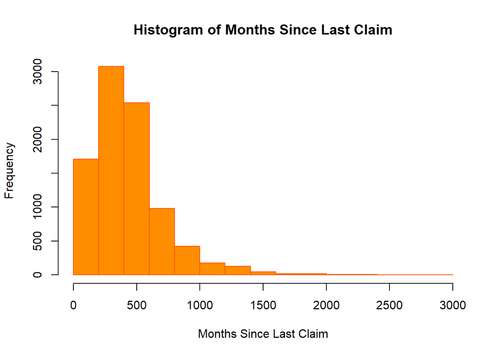

```r
hist(df$TotalClaimAmount,
     main = "Histogram of Months Since Last Claim",
     xlab = "Months Since Last Claim",
     col = "#FF8D00" ,border = "#FF5500")
```

There is a Positive Correlation of 22.65 % of TCA with CLV.

#### OUTLIER ANALYSIS OF OTHER CONTINOUS INDEPENDENT VARIABLE

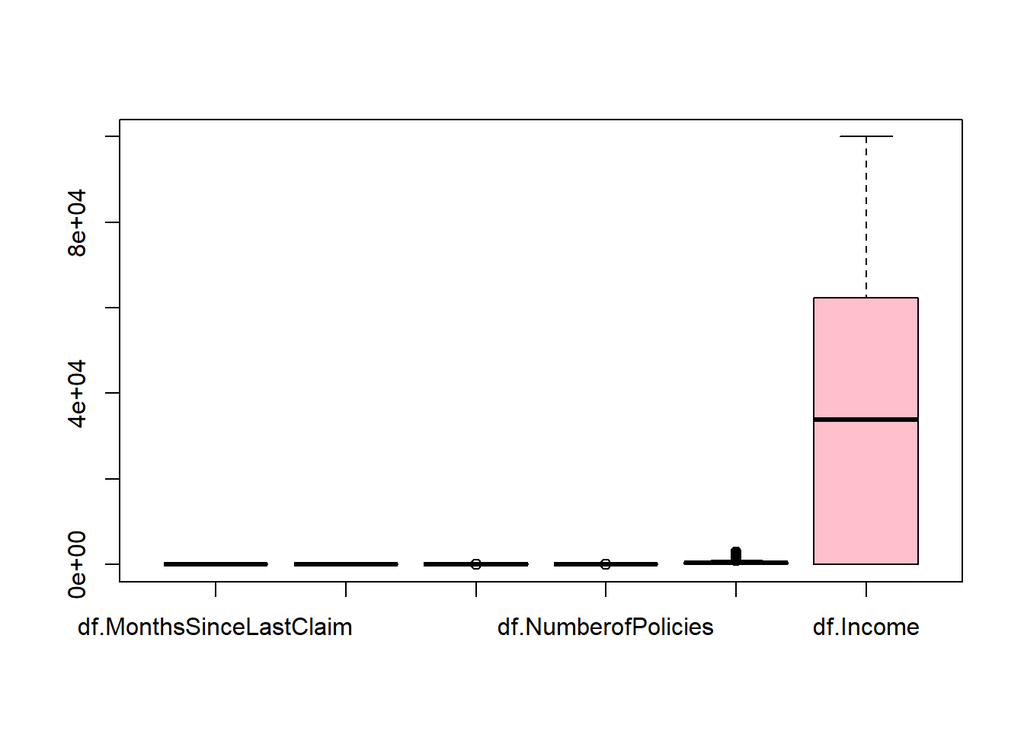

```r
databox=data.frame(df$MonthsSinceLastClaim,
df$MonthsSincePolicyInception,
df$NumberofOpenComplaints,
df$NumberofPolicies,
df$TotalClaimAmount,
df$Income)
boxplot(databox,col="pink")
```

The number of outliers is significantly low for relatively uncorrelated continuous variables.

#### RELATIONSHIP BETWEEN CATEGORICAL VARIABLES AND TARGET VARIABLE

#### Proportion of Gender for each state

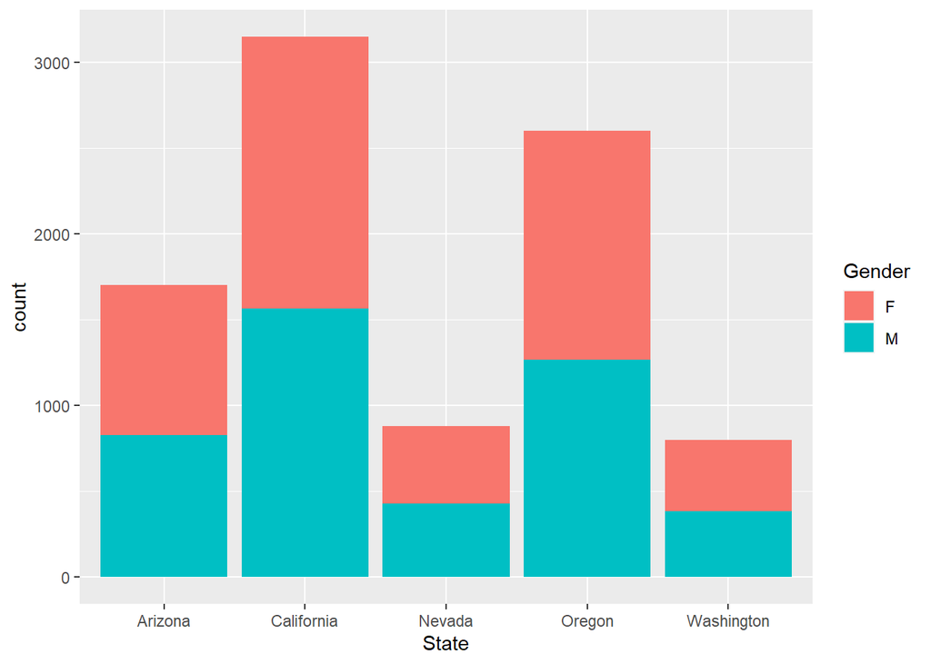

```r
ggplot(data,
       aes(x = State,
           fill = Gender)) +
  geom_bar(position = "stack")
```

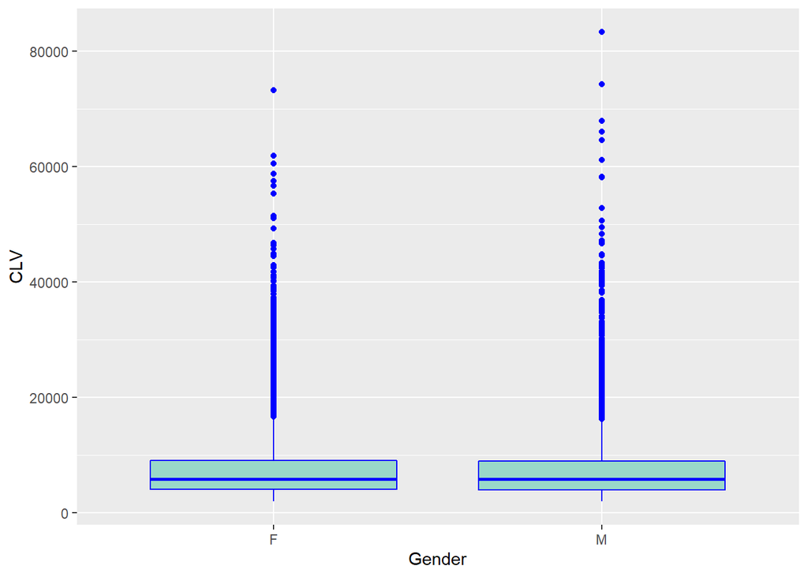

```r
ggplot(df, aes(x = Gender, y = CLV)) +
  geom_boxplot(col = "blue",outlier.colour = "blue",fill ="#99D8C9")
```

Most of the customers are from the region of California.Here we can observe that there is an equal porportion of Male and Female in all the cases and some of the male customers have highly contributed to the Customer Lifetime Value.

#### Mean Customer Lifetime Value for each Sate

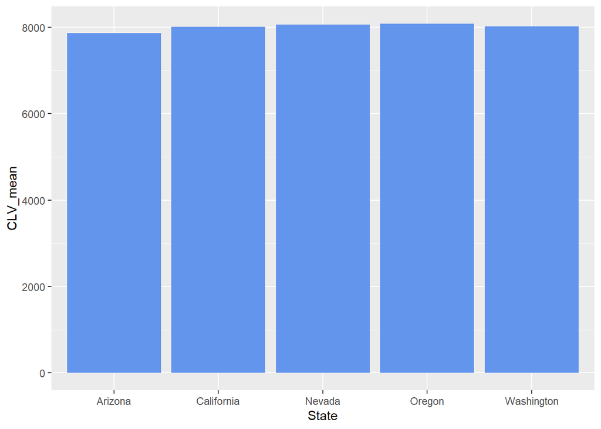

```r
plotdata <- data %>%
  group_by(State) %>%
  summarize(CLV_mean = mean(CLV))

# plot mean Customer Lifetime Value
ggplot(plotdata,
       aes(x = State,
           y = CLV_mean)) +
   geom_text(aes(label = CLV_mean),
            size = 3,
            position = position_stack(vjust = 0.5)) +
  geom_bar(stat = "identity",fill = "cornflowerblue")
```

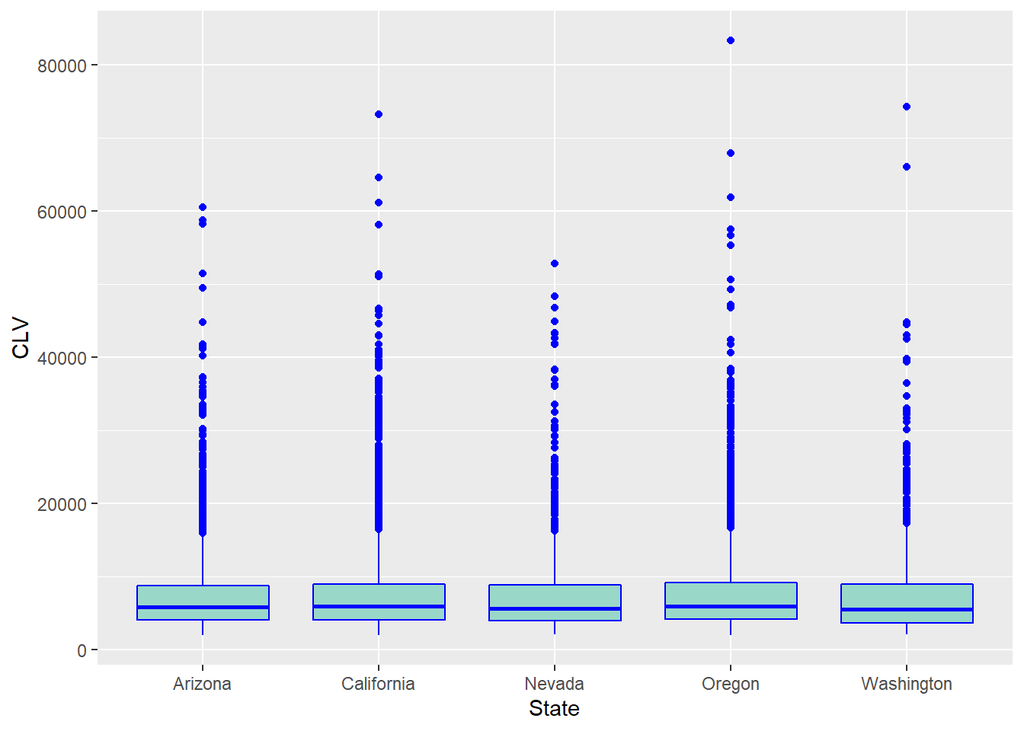

```r
ggplot(df, aes(x = State, y = CLV)) +
  geom_boxplot(col = "blue",outlier.colour = "blue",fill ="#99D8C9")
```

The average Customer Lifetime Value is somewhat same for all states but some customers from California,Washington and Oregon stands apart.

#### Mean Customer Lifetime Value for each Coverage

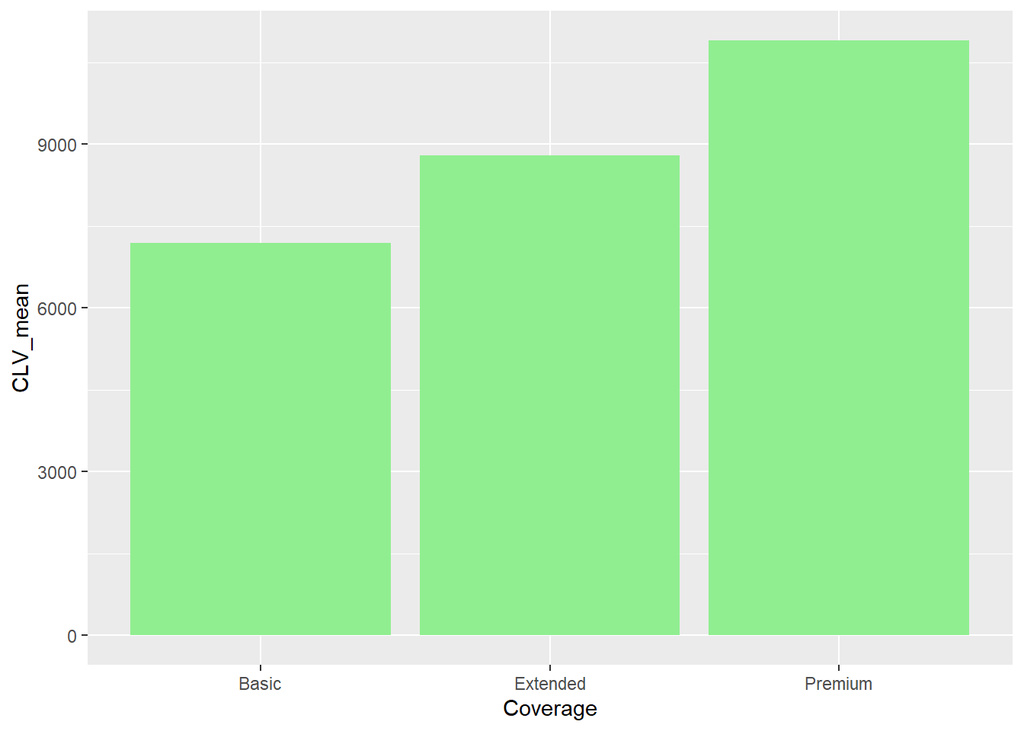

```r
plotdata <- data %>%
  group_by(Coverage) %>%
  summarize(CLV_mean = mean(CLV))

# plot mean Customer Lifetime Value
ggplot(plotdata,
       aes(x =Coverage,
           y = CLV_mean)) +
   geom_text(aes(label = CLV_mean),
            size = 3,
            position = position_stack(vjust = 0.5)) +
  geom_bar(stat = "identity",fill = "lightgreen")
```

Here we can observe that the basic policy coverage chosen by the customers has the least average Customer Lifetime Value and preminum policy coverage has the highest and this is so obvious because the high profit providing will surely choose the best coverage and vice versa.

#### Count of customers from each Education

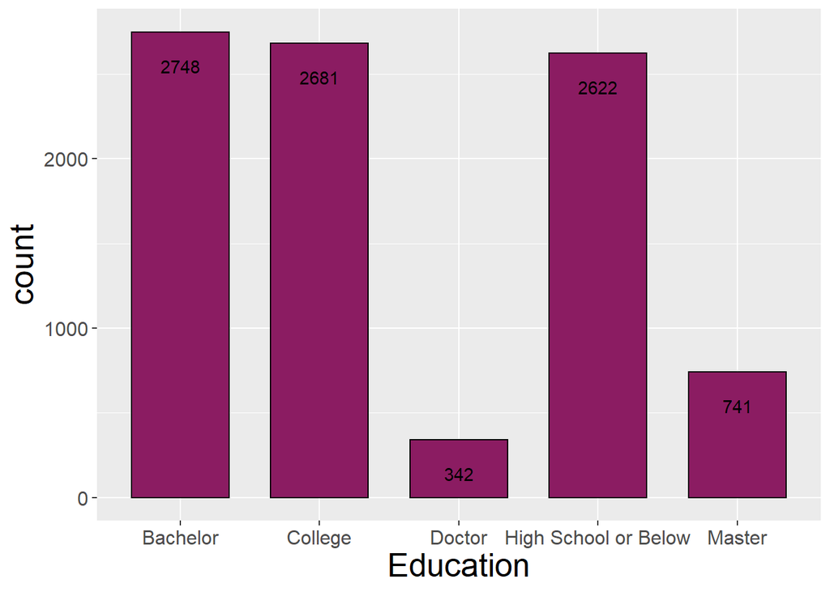

```r
ggplot(data,
       aes(x = Education)) +
  geom_bar(position = "identity",fill = "maroon4",col="black",width=0.7)+
    geom_text(stat="Count",aes(label = after_stat(count)),vjust=3)+
    theme(
        text=element_text(size=15),
        axis.title.x = element_text(color="black", size=20),
        axis.title.y = element_text(color="black", size=20)
    )
```

The number of Doctors and Masters are comparitively very low.

#### Mean Customer Lifetime Value for each Education

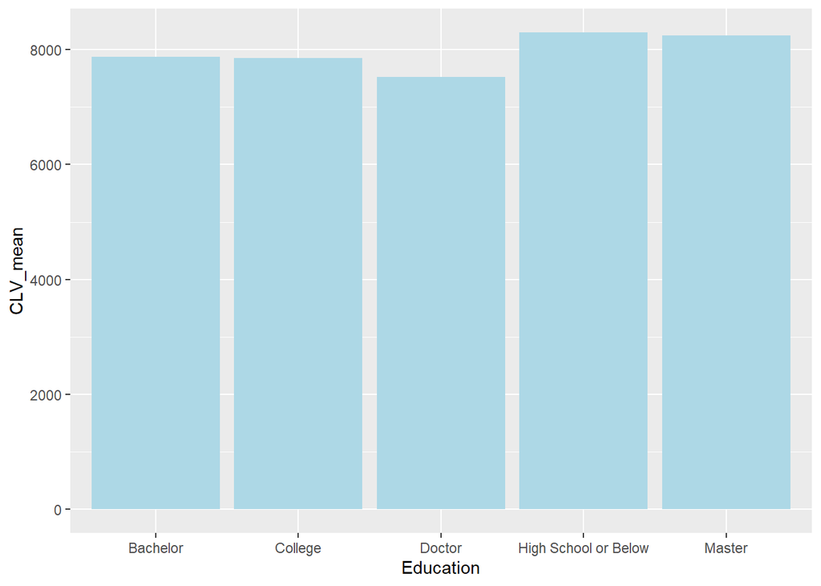

```r
plotdata <- data %>%
  group_by(Education) %>%
  summarize(CLV_mean = mean(CLV))

# plot mean Customer Lifetime Value
ggplot(plotdata,
       aes(x =Education,
           y = CLV_mean)) +
   geom_text(aes(label = CLV_mean),
            size = 3,
            position = position_stack(vjust = 0.5)) +
  geom_bar(stat = "identity",fill = "lightblue")
```

Eventhough the number of doctors is low Mean Customer Lifetime Value for that category doesn’t show much variation when compared with others and the masters education category has a high Mean Customer Lifetime Value evenif their frequency is low.

#### Count of customers from each Employment Status

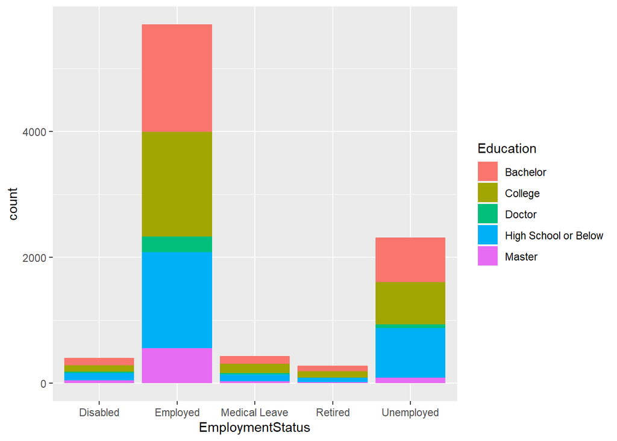

```r
ggplot(data,
       aes(x = EmploymentStatus,
           fill = Education)) +
  geom_bar(position = "stack")
```

#### Mean Customer Lifetime Value for each Employment Status

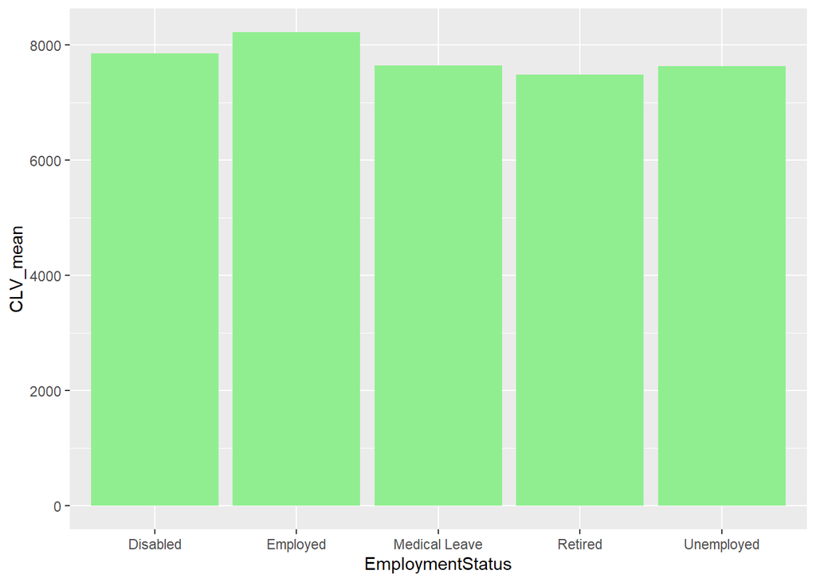

```r
plotdata <- data %>%
  group_by(EmploymentStatus) %>%
  summarize(CLV_mean = mean(CLV))

# plot mean Customer Lifetime Value
ggplot(plotdata,
       aes(x =EmploymentStatus,
           y = CLV_mean)) +
   geom_text(aes(label = CLV_mean),
            size = 3,
            position = position_stack(vjust = 0.5)) +
  geom_bar(stat = "identity",fill = "lightgreen")
```

Since the number of employed customers is high for obvious reasons the Mean Customer Lifetime Value will be high for them.

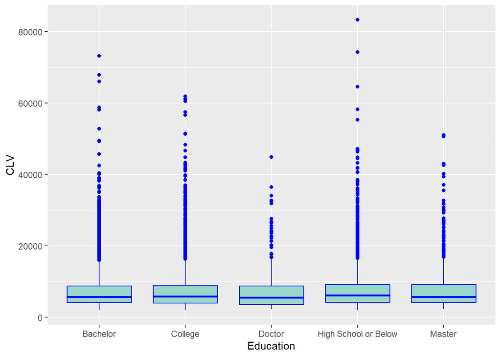

```r
ggplot(df, aes(x = Education, y = CLV)) +
  geom_boxplot(col = "blue",outlier.colour = "blue",fill ="#99D8C9")
```

Some of the customers from High School or Below stands among the outliers and have extremely high CLV value.

#### Count of customers from each Location Code

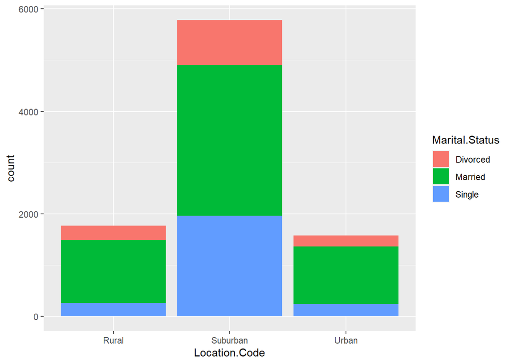

```r
ggplot(data,
       aes(x =Location.Code,
           fill = Marital.Status)) +
  geom_bar(position = "stack")
```

Most of the customers are from the suburban area then comes the rural followed by urban.Married surburban customers are valuable to the company.

#### Mean Customer Lifetime Value for each Location Code

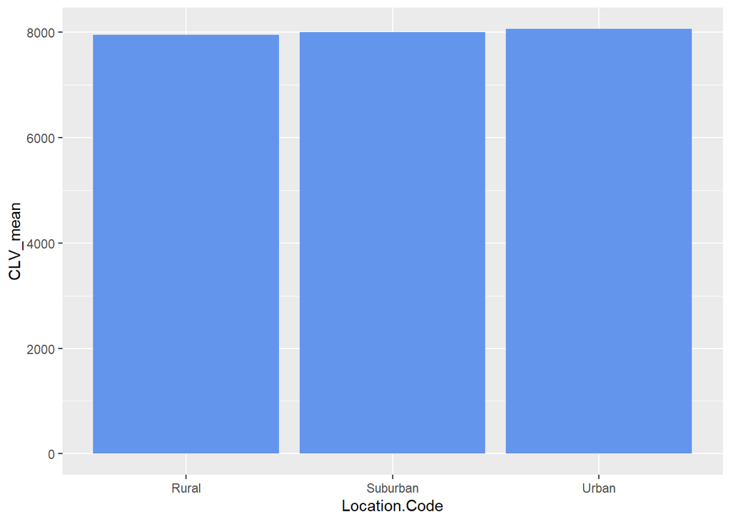

```r
plotdata <- data %>%
  group_by(Location.Code) %>%
  summarize(CLV_mean = mean(CLV))

# plot mean Customer Lifetime Value
ggplot(plotdata,
       aes(x =Location.Code,
           y = CLV_mean)) +
   geom_text(aes(label = CLV_mean),
            size = 3,
            position = position_stack(vjust = 0.5)) +
  geom_bar(stat = "identity",fill = "cornflowerblue")
```

Here we can observe that the Mean Customer Lifetime Value for the urban customers is slight higher than that of other customers this maybe because urban tend to purchase from big corporates and they have better jobs.

#### Count of customers from each Marital Status

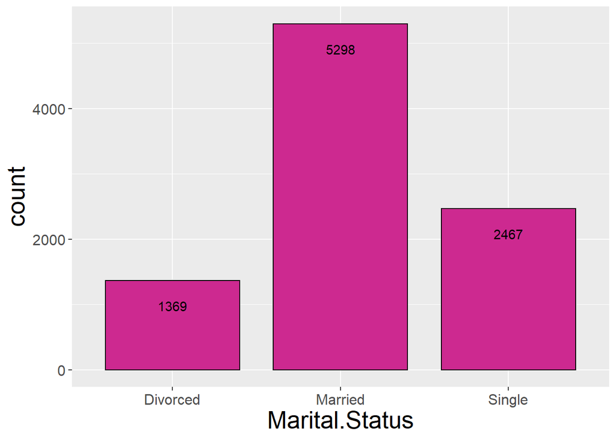

```r
ggplot(data,
       aes(x = Marital.Status)) +
  geom_bar(position = "identity",fill = "maroon3",col="black",width=0.8)+
    geom_text(stat="Count",aes(label = after_stat(count)),vjust=3)+
    theme(
        text=element_text(size=15),
        axis.title.x = element_text(color="black", size=20),
        axis.title.y = element_text(color="black", size=20)
    )
```

#### Mean Customer Lifetime Value for each Marital Status

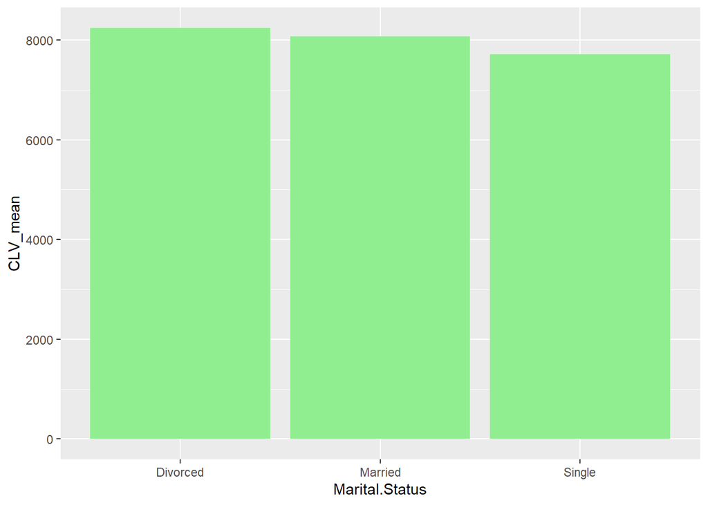

```r
plotdata <- data %>%
  group_by(Marital.Status) %>%
  summarize(CLV_mean = mean(CLV))

# plot mean Customer Lifetime Value
ggplot(plotdata,
       aes(x =Marital.Status,
           y = CLV_mean)) +
   geom_text(aes(label = CLV_mean),
            size = 3,
            position = position_stack(vjust = 0.5)) +
  geom_bar(stat = "identity",fill = "lightgreen")
```

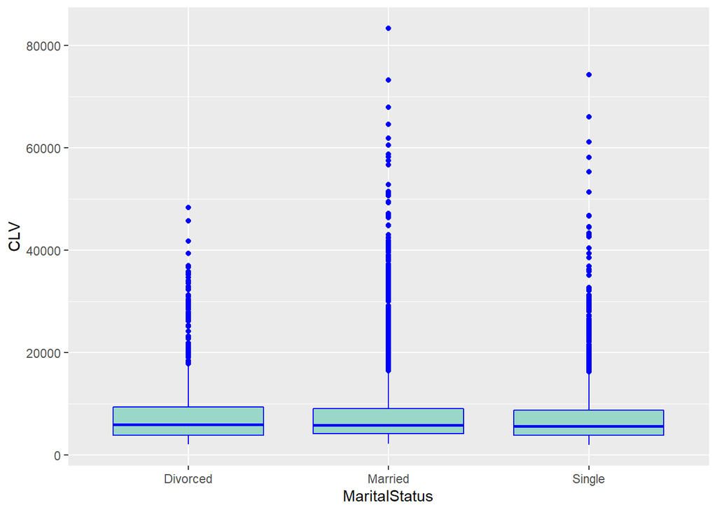

```r
ggplot(df, aes(x = MaritalStatus, y = CLV)) +
  geom_boxplot(col = "blue",outlier.colour = "blue",fill ="#99D8C9")
```

Some of the married customers have very high CLV.

#### Count of customers from each Policy Type

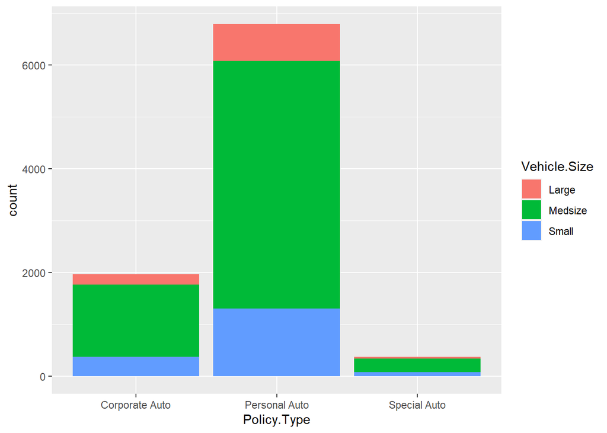

```r
par(mfrow=c(1,2))
ggplot(data,
       aes(x = Policy.Type,
           fill = Vehicle.Size)) +
  geom_bar(position = "stack")
```

The number of customers belonging to personal auto policy type is significantly high when compared with others and special auto policy type is significantly low and there is a signficantly high number of medium sized vehicles in all cases.

#### Mean Customer Lifetime Value for each Policy Type

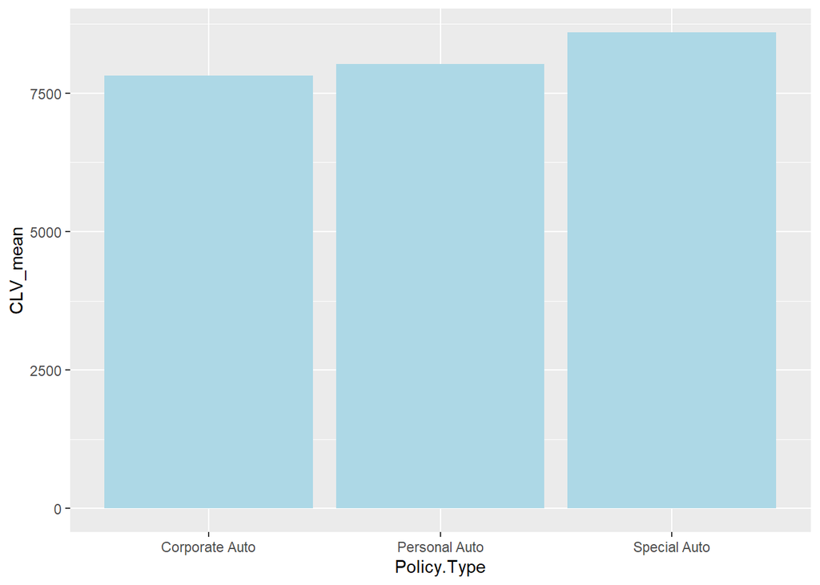

```r
plotdata <- data %>%
  group_by(Policy.Type) %>%
  summarize(CLV_mean = mean(CLV))

# plot mean Customer Lifetime Value
ggplot(plotdata,
       aes(x =Policy.Type,
           y = CLV_mean)) +
   geom_text(aes(label = CLV_mean),
            size = 3,
            position = position_stack(vjust = 0.5)) +
  geom_bar(stat = "identity",fill = "lightblue")
```

Here we can observe that the special auto policy type has a high Mean Customer Lifetime Value eventhough the count is that case is very low, from this we can conclude that the special auto policy is not vehicles with high cost or are heavy goods vehicles.

#### Count of customers from each Policy

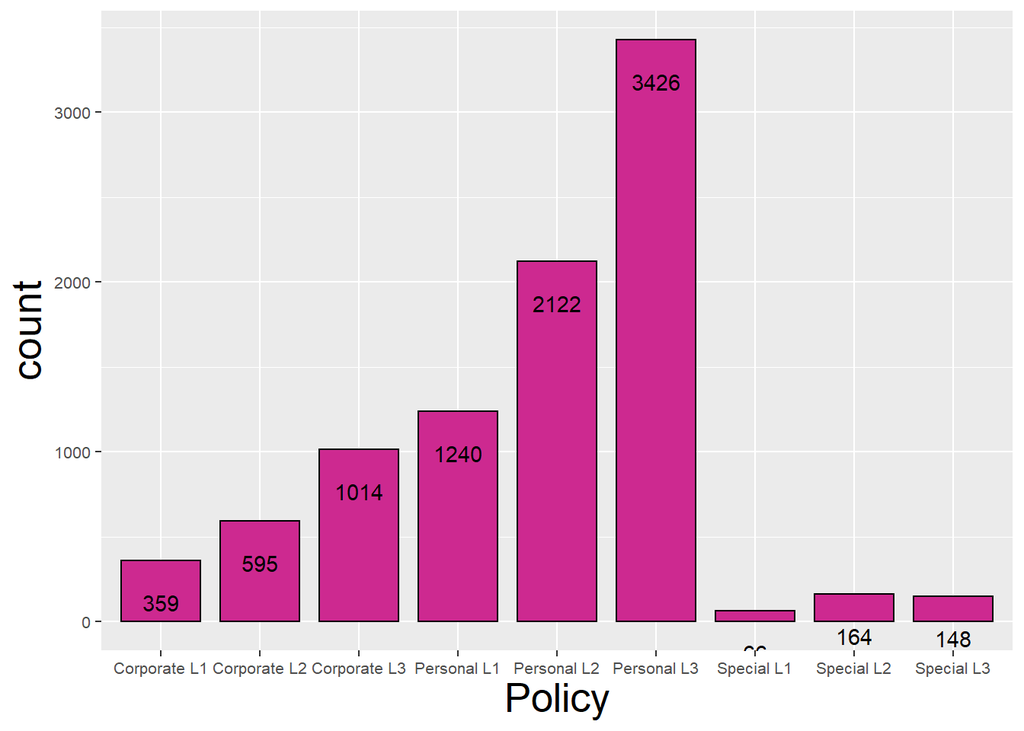

```r
ggplot(data,
       aes(x = Policy)) +
  geom_bar(position = "identity",fill = "maroon3",col="black",width=0.8)+
    geom_text(stat="Count",aes(label = after_stat(count)),vjust=3)+
    theme(
        text=element_text(size=10),
        axis.title.x = element_text(color="black", size=20),
        axis.title.y = element_text(color="black", size=20)
    )
```

Here we case observe that the personal L3 customers are high in numbers when compare with others.

#### Mean Customer Lifetime Value for each Policy

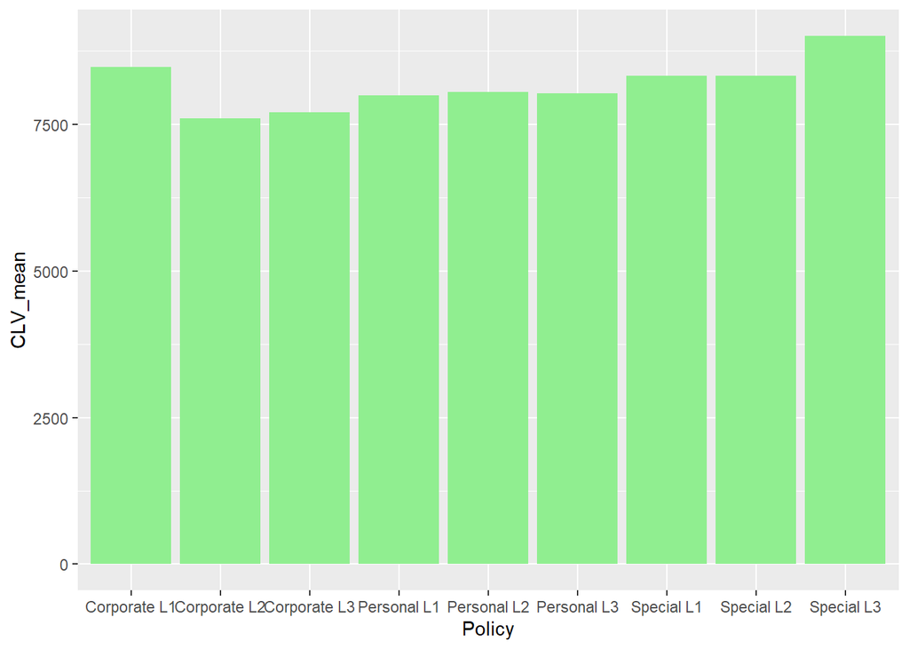

```r
plotdata <- data %>%
  group_by(Policy) %>%
  summarize(CLV_mean = mean(CLV))

# plot mean Customer Lifetime Value
ggplot(plotdata,
       aes(x =Policy,
           y = CLV_mean)) +
   geom_text(aes(label = CLV_mean),
            size = 1,
            position = position_stack(vjust = 0.9)) +
  geom_bar(stat = "identity",fill = "lightgreen")
```

#### Count of customers from each Renew Offer Type

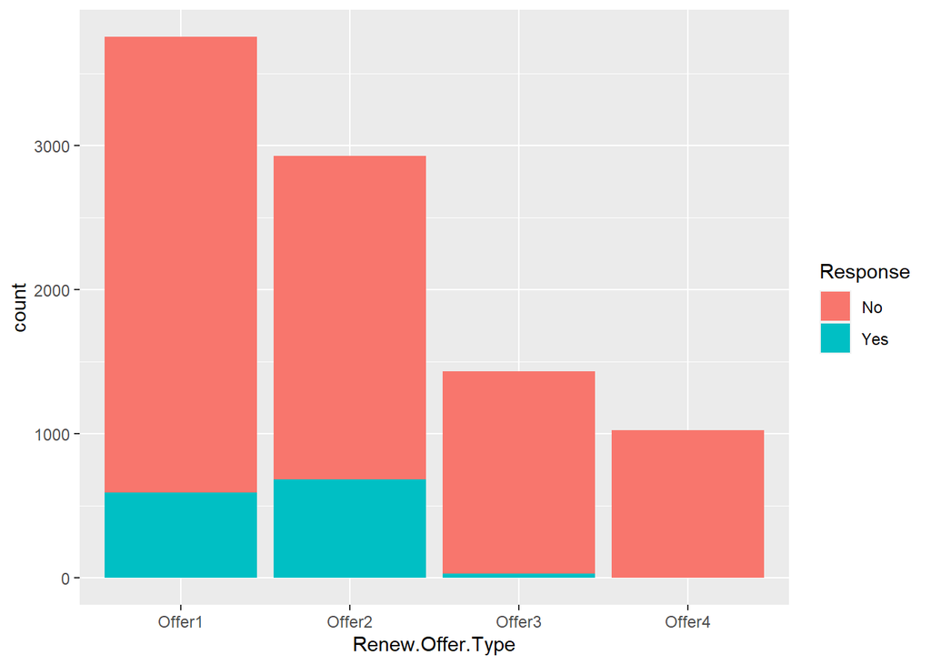

```r
ggplot(data,
       aes(x = Renew.Offer.Type,
           fill = Response)) +
  geom_bar(position = "stack")
```

Most of the customers picked up offer 1 class renewal type because it provides maximum benefits to the customers followed by offer 2 , offer 3 and so on, from this we can conclude that customer chooses renewal based on the benefits provided by the company and customers belonging to offer 4 class renewal type had a negative response to the policy plan

#### Mean Customer Lifetime Value for each Renew Offer Type

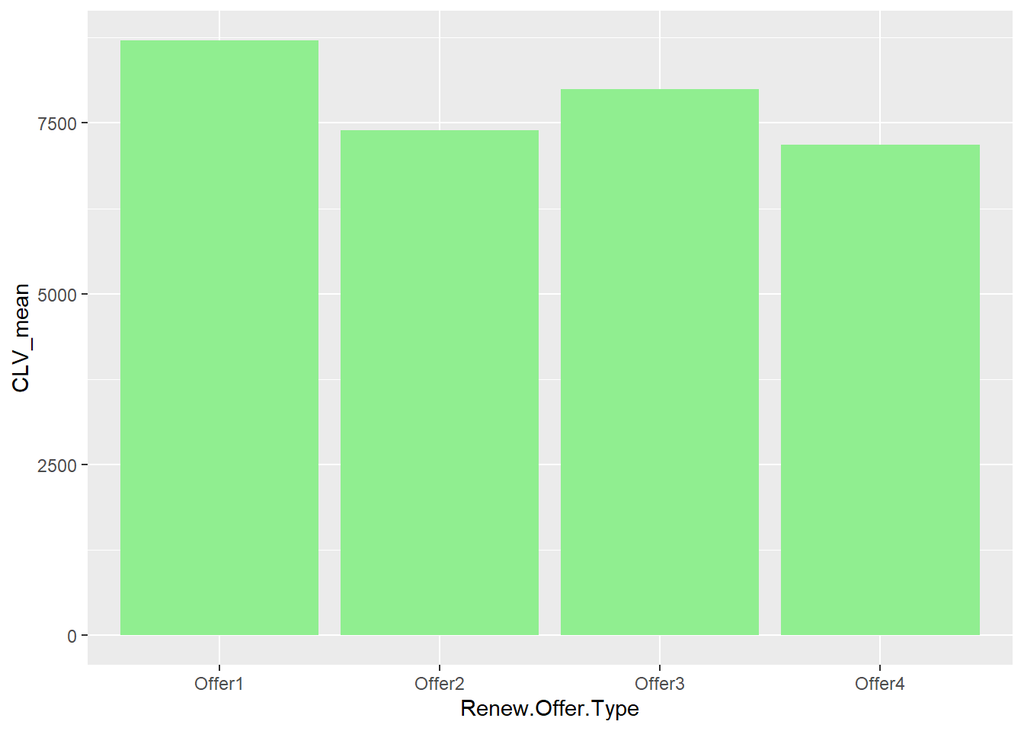

```r
plotdata <- data %>%
  group_by(Renew.Offer.Type) %>%
  summarize(CLV_mean = mean(CLV))

# plot mean Customer Lifetime Value
ggplot(plotdata,
       aes(x =Renew.Offer.Type,
           y = CLV_mean)) +
   geom_text(aes(label = CLV_mean),
            size = 3,
            position = position_stack(vjust = 0.5)) +
  geom_bar(stat = "identity",fill = "lightgreen")
```

Here we can observe that offer 1 class renewal type has the highest Mean Customer Lifetime Value, this is because they enjoy maximum benefits from the company and is obliged to increase the profit of the company.On a different perspective we can say that, the customer who is favouring the company the most will be given maximum benefits, the company best possibly retains customers providing maximum profit and does not give much consideration to less profit providing customers and that is the reason why the count in those class renewal category is low.

#### Count of customers from each Sales Channel

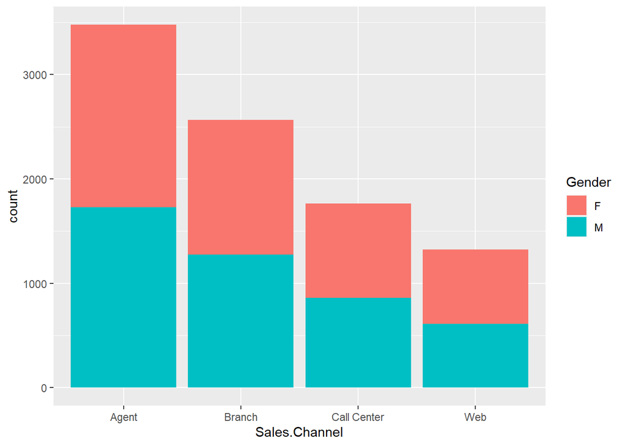

```r
ggplot(data,
       aes(x = Sales.Channel,
           fill = Gender)) +
  geom_bar(position = "stack")
```

Most of the customers used Agent Sales Channel irrespective of the gender and it is followed by branch, call center and then web.